# Friendship!!!

My friends and I have a colaboratory playlist called [Dadesurs](https://open.spotify.com/playlist/2dDtStk8Nk1PP0JxvdgPEK).

This script was created to show the contents and statistics of the playlist, and automatically send reminders to add songs to it.

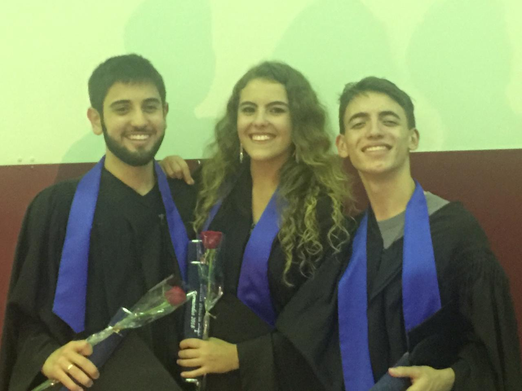

## Code

### Setup

Library loading and custom displaying functions:

```python
# Spotpy and credential utilities:
from dotenv import load_dotenv
from os import getenv, listdir
import spotipy

# Data manipulation:
import polars as pl
from collections import Counter
import re
import random as rd
from emoji import EMOJI_DATA
import base64

# Email sending:
import smtplib
from email.mime.multipart import MIMEMultipart
from email.mime.text import MIMEText
from email.mime.image import MIMEImage

# Custom dataframe printing:
from IPython.display import display, Markdown
from itables import init_notebook_mode, show
init_notebook_mode(all_interactive=True)

def print_df(data, n = 5, as_md = True):
    config = pl.Config(
        tbl_hide_dataframe_shape = True,
        tbl_hide_column_data_types = True,
        tbl_formatting = 'ASCII_MARKDOWN' if as_md else 'UTF8',
        tbl_rows = n
    )

    with config:
        if as_md:
            display(Markdown(repr(data)))
        else:
            print(data)

    return None
```

### Spotfy conection

Loading credentials from the enviroment variables and connecting to the Spotify API:

```python
load_dotenv()

auth = spotipy.oauth2.SpotifyOAuth(
    client_id = getenv("SPOTIPY_CLIENT_ID"),
    client_secret = getenv("SPOTIPY_CLIENT_SECRET"),
    redirect_uri = getenv("SPOTIPY_REDIRECT_URI"),
    scope = "user-library-read"
)

sp = spotipy.Spotify(auth_manager = auth)
```

### Tracks’ data extraction

Extracting the tracks via the playlist ID, and extracting their data:

- User names, customized via a lookup table.
- Track names, with ” (feat. …)” and ” - Remastered …” type comments removed, via the `"(.+) (\(.+\)|- .+)$"` regex.
- Artist (the main one) and popularity index.
- Duration, converted to seconds.
- Added date, removing the HH:MM:SS part with string indexing.

```python
tracks = sp.playlist_tracks("2dDtStk8Nk1PP0JxvdgPEK")["items"]

ids_dict = {
    "wh946a5syk0vfqe3538avp6xd": "Lau 🤠",
    "21m2c7t3edlhzjpcoifnnca6y": "Ric 😝",
    "arthur81u": "Atu 🥴"
}

data = pl.DataFrame({
    "User": [ids_dict[x] for x in [x["added_by"]["id"] for x in tracks]],
    "Track": [re.sub(r"(.+) (\(.+\)|- .+)$", r"\1", x["track"]["name"]) for x in tracks],
    "Artist": [x["track"]["artists"][0]["name"] for x in tracks],
    "Popularity": [x["track"]["popularity"] for x in tracks],
    "Duration": [x["track"]["duration_ms"] / 1000 for x in tracks],
    "Added Date": [x["added_at"][0:10] for x in tracks]
})
```

### Data visualizations

For each user, getting aggregated stats, via Polars’ `group_by` + `agg` methods:

- Number of tracks added.
- Average popularity of the tracks.
- Average duration, stylized into MmSS format.

```python
data_avg = data.group_by("User").agg([
    pl.col("User").count().alias("# Tracks"),
    pl.col("Popularity").mean().round(1).alias("Avg. Popularity"),
    pl.col("Duration").mean().alias("Avg. Duration")
]).with_columns(
    pl.col("Avg. Duration").map_elements(
        lambda s: f"{int(s//60)}m{int(s%60):02d}",
        return_dtype = str
    )
).sort(
    ("# Tracks", "User"), descending = (True, False)
)
```

Full data:

```python
data_full = data.with_columns(pl.col("Duration").map_elements(
    lambda s: f"{int(s//60)}m{int(s%60):02d}",
    return_dtype = str
)).sort(
    ("Added Date", "User")
)
```

## Statistics

### Average stats

```python
print_df(data_avg)
```

| User | # Tracks | Avg. Popularity | Avg. Duration |
| --- | --- | --- | --- |
| Atu 🥴 | 18 | 49.7 | 3m58 |
| Ric 😝 | 18 | 49.8 | 3m40 |
| Lau 🤠 | 15 | 50.0 | 3m07 |

### Full table

```python
show(
    data_full,
    paging = False,
    scrollY = "500px",
    classes = "display nowrap compact table-striped small hover"
)
```

User

Track

Artist

Popularity

Duration

Added Date

[figure not shown]

Loading ITables v2.2.4 from the `init_notebook_mode` cell... (need [help](https://mwouts.github.io/itables/troubleshooting.html)?)

## Reminders

Now, onto the automatic email reminders.

The first step is to randomize the subject line, and the content (a picture of us and a music-related quote).

```python
def get_random_color():
    return f"rgba({rd.randint(0, 256)}, {rd.randint(0, 256)}, {rd.randint(0, 256)}, 0.8)"

subject = rd.choice([
    'Ponha, ponha a musga imediatamente 🔪',
    'Cadê as músicas, seus vacilões? 🎶',
    'A playlist não vai se encher sozinha! 🚀',
    'Vamos lá, DJ! Solta o som! 🎧',
    'Sem música, sem festa! 🎉',
    'Não seja tímido, queremos te ouvir! 🎵',
    'A megacorporação Spotfy TM exige mais músicas! 🤖',
])

img_path = rd.choice(listdir('pictures/'))

with open('quotes.txt', 'r', encoding="utf-8") as file:
    quote = rd.choice([quote.strip() for quote in file.readlines()])

components = {
    "background-color": get_random_color(),
    "foreground-color": get_random_color(),
    "quote": quote
}
```

Then, these contents are injected in a HTML template, that has tags of the form `"@@tag@@"`. The code is partially taken from the template_injector Python package that I created.

```python
with open('email_template.html', 'r', encoding="utf-8") as file:
    template = file.read()

# From https://github.com/ricardo-semiao/ricardo-semiao/tree/main/packages/template_injector
for key, value in components.items():
    pattern = re.compile('@@' + re.escape(key) + '@@')
    match = re.search(pattern, template)

    template = re.sub(f'@@{key}@@', value, template)
```

Lastly, the email is sent via SMTP. The user data is stored in the environment variables, and the content is build with MIME, specially the image attachment via CID.

```python
smtp_server = 'smtp.gmail.com'
smtp_port = 587
smtp_user = getenv("GMAIL_USER")
smtp_password = getenv("GMAIL_APP_PASSWORD")

from_email = getenv("GMAIL_USER")
receivers = [getenv("GMAIL_LAULA"), getenv("GMAIL_ATU")]

for to_email in receivers:
    msg = MIMEMultipart()
    msg['From'] = from_email
    msg['To'] = to_email
    msg['Subject'] = subject
    msg.attach(MIMEText(template, 'html'))

    with open(f'pictures/{img_path}', "rb") as file:
        img = MIMEImage(file.read())
        img.add_header('Content-ID', '<image1>')
        msg.attach(img)

    try:
        server = smtplib.SMTP(smtp_server, smtp_port)
        server.starttls()
        server.login(smtp_user, smtp_password)
        server.sendmail(from_email, to_email, msg.as_string())
        server.quit()
        print(f'Email sent successfully to {to_email}')
    except Exception as e:
        print(f'Failed to send email: {e}')
```

An example email is shown below:

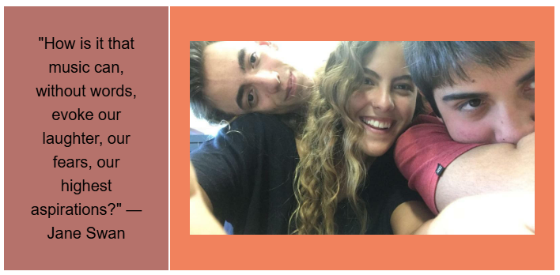